# QK Box 11.2

Legault et al. (2018) experimentally examined the effects of nutrient loading on the outcome of competitive interactions between two species of saltmarsh plants, the native *Spartina alterniflora* and the exotic *Phragmites australis*, in northeast USA. The between-plots factor was nutrient addition (fixed, with three groups: none, low and high) with five 50-gallon bins containing half-strength seawater as the plots. The within-plots factor was competition (fixed with two groups: no competition, with competition), with sub-plots being small pots containing one (no competition) or both (with competition) species within each bin. This design was replicated at the sub-plot level with two pots for each competition group within each bin. We will analyze biomass of *P. australis* at ambient temperature as the response variable.

[figure not shown]

*Phragmites australis*. Mick Keough, [CC BY 4.0](https://creativecommons.org/licenses/by-sa/4.0)

The paper is [here](https://doi.org/10.1371/journal.pone.0100718)

Legault, R., Zogg, G. P. & Travis, S. E. (2018). Competitive interactions between native *Spartina alterniflora* and non-native *Phragmites australis* depend on nutrient loading and temperature. *PLoS One*, 13, e0192234.

### Preliminaries

First, load the required packages (afex, car, lattice, lme4, lmerTest, nlme, VCA, ez, emmeans, Rmisc, MuMIn)

Import legault data file (legault.csv)

```r
legault <- read.csv("../data/legault.csv")
legault
```

| bin | comp | nutrient | biom | biomadj |
| --- | --- | --- | --- | --- |
| A1 | No Competition | Null (0 g N/m2/year) | 6.91 | -21.383500 |
| A1 | No Competition | Null (0 g N/m2/year) | 15.34 | -15.493400 |
| A1 | With Competition | Null (0 g N/m2/year) | 4.51 | -23.549900 |
| A1 | With Competition | Null (0 g N/m2/year) | 4.97 | -24.526600 |
| A2 | No Competition | High (120 g N/m2/year) | 62.75 | 41.942540 |
| A2 | No Competition | High (120 g N/m2/year) | 36.26 | 6.362312 |
| A2 | With Competition | High (120 g N/m2/year) | 35.78 | 6.149672 |
| A2 | With Competition | High (120 g N/m2/year) | 32.77 | 0.298714 |
| A4 | No Competition | High (120 g N/m2/year) | 78.90 | 45.125600 |
| A4 | No Competition | High (120 g N/m2/year) | 74.17 | 39.727200 |

[output cut: 50 more lines]

Set contrasts from afex

Re-arrange nutrient levels so that no nutrients is reference

```r
set_sum_contrasts()
```

```
setting contr.sum globally: options(contrasts=c('contr.sum', 'contr.poly'))
```

```r
legault$nutrient <- factor(legault$nutrient, levels=c("Null (0 g N/m2/year)","Low (30 g N/m2/year)","High (120 g N/m2/year)"))
legault$comp<-factor(legault$comp)
```

### Fit aov crossed model to check approx residuals

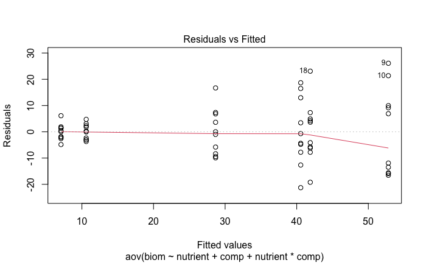

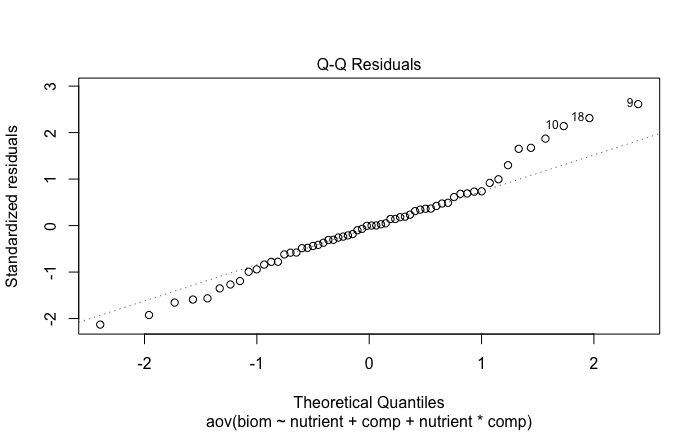

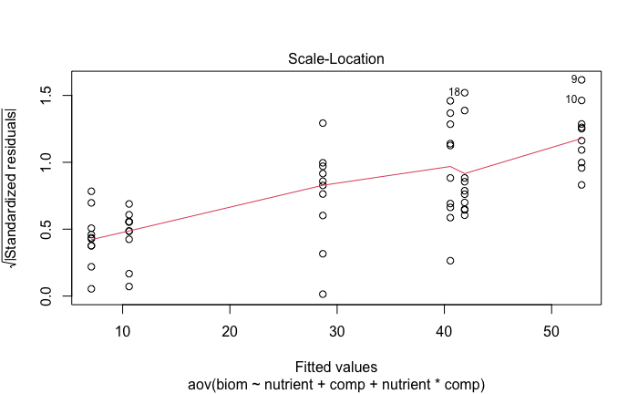

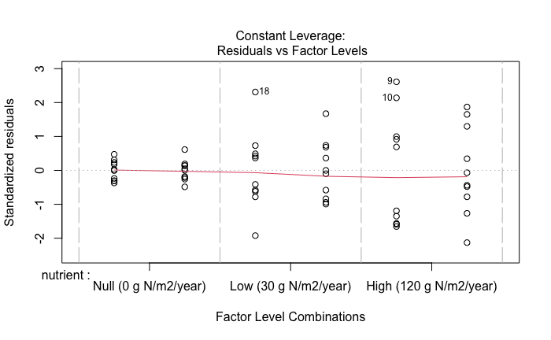

```r
legault1.aov <- aov(biom~nutrient+comp+nutrient*comp, legault)
plot(legault1.aov)
```

Some evidence for unequal residuals but use untransformed biomass to match original paper

### Fit model using aov (balanced design so all SS types the same)

```r
legault2.aov <- aov(biom~nutrient+Error(bin/comp)+comp+nutrient*comp, legault)
summary(legault2.aov)
```

```
Error: bin
          Df Sum Sq Mean Sq F value   Pr(>F)
nutrient   2  15071    7535   46.45 2.24e-06 ***
Residuals 12   1947     162
---
Signif. codes:  0 ‘***’ 0.001 ‘**’ 0.01 ‘*’ 0.05 ‘.’ 0.1 ‘ ’ 1

Error: bin:comp
              Df Sum Sq Mean Sq F value  Pr(>F)
comp           1 1400.4  1400.4   9.726 0.00888 **
nutrient:comp  2  285.4   142.7   0.991 0.39966
Residuals     12 1727.9   144.0
---
Signif. codes:  0 ‘***’ 0.001 ‘**’ 0.01 ‘*’ 0.05 ‘.’ 0.1 ‘ ’ 1

Error: Within
          Df Sum Sq Mean Sq F value Pr(>F)
Residuals 30   2314   77.12
```

```r
print(summary(legault2.aov))
```

```
Error: bin
          Df Sum Sq Mean Sq F value   Pr(>F)
nutrient   2  15071    7535   46.45 2.24e-06 ***
Residuals 12   1947     162
---
Signif. codes:  0 ‘***’ 0.001 ‘**’ 0.01 ‘*’ 0.05 ‘.’ 0.1 ‘ ’ 1

Error: bin:comp
              Df Sum Sq Mean Sq F value  Pr(>F)
comp           1 1400.4  1400.4   9.726 0.00888 **
nutrient:comp  2  285.4   142.7   0.991 0.39966
Residuals     12 1727.9   144.0
---
Signif. codes:  0 ‘***’ 0.001 ‘**’ 0.01 ‘*’ 0.05 ‘.’ 0.1 ‘ ’ 1

Error: Within
          Df Sum Sq Mean Sq F value Pr(>F)
Residuals 30   2314   77.12
```

### Fit split-plot anova model using ez for comparison of output

This uses mean biomass for each competition group within each bin - same answers as above due to balanced design

```r
legault.ez <- ezANOVA(dv=biom, wid=bin, within=comp, between=nutrient, type=1, legault)
print(legault.ez)
```

```
$ANOVA
         Effect DFn DFd          F            p p<.05        ges
1      nutrient   2  12 46.4539769 2.239943e-06     * 0.80398143
2          comp   1  12  9.7258295 8.877441e-03     * 0.27595248
3 nutrient:comp   2  12  0.9909378 3.996639e-01       0.07206656
```

### Rerun as classic split-plot design based on sub-plot means - matches above

This example illustrates a short-cut that produces a simpler analysis for a paper, etc.

```r
legault_means <- summarySE(legault, measurevar= 'biom', groupvars= c('nutrient','bin','comp'))
legault_means
```

| nutrient | bin | comp | N | biom | sd | se | ci |
| --- | --- | --- | --- | --- | --- | --- | --- |
| Null (0 g N/m2/year) | A1 | No Competition | 2 | 11.125 | 5.9609102 | 4.215 | 53.556653 |
| Null (0 g N/m2/year) | A1 | With Competition | 2 | 4.740 | 0.3252691 | 0.230 | 2.922427 |
| Null (0 g N/m2/year) | A5 | No Competition | 2 | 10.625 | 4.3487067 | 3.075 | 39.071580 |
| Null (0 g N/m2/year) | A5 | With Competition | 2 | 8.030 | 0.6646804 | 0.470 | 5.971916 |
| Null (0 g N/m2/year) | B1 | No Competition | 2 | 10.225 | 3.8395898 | 2.715 | 34.497346 |
| Null (0 g N/m2/year) | B1 | With Competition | 2 | 5.605 | 4.7729708 | 3.375 | 42.883441 |
| Null (0 g N/m2/year) | B2 | No Competition | 2 | 10.315 | 2.9486353 | 2.085 | 26.492437 |
| Null (0 g N/m2/year) | B2 | With Competition | 2 | 10.160 | 4.3133514 | 3.050 | 38.753924 |
| Null (0 g N/m2/year) | C4 | No Competition | 2 | 10.715 | 0.2333452 | 0.165 | 2.096524 |
| Null (0 g N/m2/year) | C4 | With Competition | 2 | 6.870 | 2.2910260 | 1.620 | 20.584052 |

[output cut: 20 more lines]

```r
legault3.aov <- aov(biom~nutrient*comp+Error(bin), legault_means)
summary(legault3.aov)
```

```
Error: bin
          Df Sum Sq Mean Sq F value   Pr(>F)
nutrient   2   7535    3768   46.45 2.24e-06 ***
Residuals 12    973      81
---
Signif. codes:  0 ‘***’ 0.001 ‘**’ 0.01 ‘*’ 0.05 ‘.’ 0.1 ‘ ’ 1

Error: Within
              Df Sum Sq Mean Sq F value  Pr(>F)
comp           1  700.2   700.2   9.726 0.00888 **
nutrient:comp  2  142.7    71.3   0.991 0.39966
Residuals     12  863.9    72.0
---
Signif. codes:  0 ‘***’ 0.001 ‘**’ 0.01 ‘*’ 0.05 ‘.’ 0.1 ‘ ’ 1
```

### Fit mixed model using lme4

```r
legault1.lmer <- lmer(biom~nutrient+comp+nutrient*comp+(1|bin)+(1|bin:comp), REML=TRUE, legault)
```

Get residuals from lmer model fit - some evidence on variance heterogeneity but again use untransformed biom to match original paper

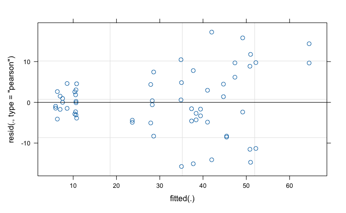

```r
plot(legault1.lmer)
```

```r
summary(legault1.lmer, ddf="Kenward-Roger")
```

```
Linear mixed model fit by REML. t-tests use Kenward-Roger's method ['lmerModLmerTest']
Formula: biom ~ nutrient + comp + nutrient * comp + (1 | bin) + (1 | bin:comp)
   Data: legault

REML criterion at convergence: 426.7

Scaled residuals:
     Min       1Q   Median       3Q      Max
-1.79289 -0.47345 -0.04004  0.51095  1.96250

Random effects:
 Groups   Name        Variance Std.Dev.
 bin:comp (Intercept) 33.432   5.782
 bin      (Intercept)  4.556   2.134
 Residual             77.124   8.782
Number of obs: 60, groups:  bin:comp, 30; bin, 15

Fixed effects:
                Estimate Std. Error      df t value Pr(>|t|)
(Intercept)       30.267      1.644  12.000  18.408 3.67e-10 ***
nutrient1        -21.426      2.325  12.000  -9.214 8.61e-07 ***
nutrient2          5.014      2.325  12.000   2.156  0.05208 .
comp1              4.831      1.549  12.000   3.119  0.00888 **
nutrient1:comp1   -3.071      2.191  12.000  -1.402  0.18629
nutrient2:comp1    1.781      2.191  12.000   0.813  0.43213
---
Signif. codes:  0 ‘***’ 0.001 ‘**’ 0.01 ‘*’ 0.05 ‘.’ 0.1 ‘ ’ 1

Correlation of Fixed Effects:
            (Intr) ntrnt1 ntrnt2 comp1  ntr1:1
nutrient1    0.000
nutrient2    0.000 -0.500
comp1        0.000  0.000  0.000
ntrnt1:cmp1  0.000  0.000  0.000  0.000
ntrnt2:cmp1  0.000  0.000  0.000  0.000 -0.500
```

```r
anova(legault1.lmer, ddf="Kenward-Roger")
```

```
Type III Analysis of Variance Table with Kenward-Roger's method
              Sum Sq Mean Sq NumDF DenDF F value   Pr(>F)
nutrient      7165.4  3582.7     2    12 46.4540 2.24e-06 ***
comp           750.1   750.1     1    12  9.7258 0.008877 **
nutrient:comp  152.8    76.4     2    12  0.9909 0.399664
---
Signif. codes:  0 ‘***’ 0.001 ‘**’ 0.01 ‘*’ 0.05 ‘.’ 0.1 ‘ ’ 1
```

Contrast no nutrients with low and high separately

```r
legault1.emm <- emmeans(legault1.lmer, ~nutrient)
```

```
NOTE: Results may be misleading due to involvement in interactions
```

```r
legault1.con <- contrast(legault1.emm, "trt.vs.ctrl", ref=1)
summary(legault1.con, adjust="none")
```

```
 contrast                                          estimate   SE df t.ratio p.value
 (Low (30 g N/m2/year)) - (Null (0 g N/m2/year))       26.4 4.03 12   6.565  <.0001
 (High (120 g N/m2/year)) - (Null (0 g N/m2/year))     37.8 4.03 12   9.395  <.0001

Results are averaged over the levels of: comp
Degrees-of-freedom method: kenward-roger
```

Get variance components with CIs

```r
legault1.ci <- confint.merMod(legault1.lmer, oldNames=FALSE)
```

```
Computing profile confidence intervals ...
```

```r
legault1.vc <- (legault1.ci)^2
print(legault1.vc)
```

```
                              2.5 %       97.5 %
sd_(Intercept)|bin:comp   0.0000000   69.8785882
sd_(Intercept)|bin        0.0000000   46.7902117
sigma                    48.3597992  132.4605475
(Intercept)             739.2584171 1111.8018654
nutrient1               664.4696090  291.5109541
nutrient2                 0.4378363   87.7089963
comp1                     3.8408980   59.3286228
nutrient1:comp1          50.8634666    0.9791549
nutrient2:comp1           5.1977743   34.1233859
```

Evaluate whether to omit bins(nutrients) x competition interaction

```r
legault1a.lmer <- lmer(biom~nutrient+comp+nutrient*comp+(1|bin)+(1|bin:comp), REML=FALSE, legault)
legault2.lmer <- lmer(biom~nutrient+comp+nutrient*comp+(1|bin), REML=FALSE, legault)
anova(legault1a.lmer,legault2.lmer)
```

```
Data: legault
Models:
legault2.lmer: biom ~ nutrient + comp + nutrient * comp + (1 | bin)
legault1a.lmer: biom ~ nutrient + comp + nutrient * comp + (1 | bin) + (1 | bin:comp)
               npar    AIC    BIC  logLik deviance  Chisq Df Pr(>Chisq)
legault2.lmer     8 461.66 478.41 -222.83   445.66
legault1a.lmer    9 462.82 481.67 -222.41   444.82 0.8365  1     0.3604
```

```r
AICc(legault1a.lmer,legault2.lmer)
```

|  | df | AICc |
| --- | --- | --- |
| legault1a.lmer | 9 | 466.4203 |
| legault2.lmer | 8 | 464.4804 |

Get results from model omiting bins(nutrients) x competition interaction

```r
legault2a.lmer <- lmer(biom~nutrient+comp+nutrient*comp+(1|bin), REML=TRUE, legault)
summary(legault2a.lmer)
```

```
Linear mixed model fit by REML. t-tests use Satterthwaite's method ['lmerModLmerTest']
Formula: biom ~ nutrient + comp + nutrient * comp + (1 | bin)
   Data: legault

REML criterion at convergence: 428.5

Scaled residuals:
     Min       1Q   Median       3Q      Max
-1.87288 -0.46690 -0.01945  0.52482  2.17844

Random effects:
 Groups   Name        Variance Std.Dev.
 bin      (Intercept) 16.50    4.062
 Residual             96.23    9.810
Number of obs: 60, groups:  bin, 15

Fixed effects:
                Estimate Std. Error      df t value Pr(>|t|)
(Intercept)       30.267      1.644  12.000  18.408 3.67e-10 ***
nutrient1        -21.425      2.325  12.000  -9.214 8.61e-07 ***
nutrient2          5.014      2.325  12.000   2.156 0.052077 .
comp1              4.831      1.266  42.000   3.815 0.000441 ***
nutrient1:comp1   -3.071      1.791  42.000  -1.715 0.093753 .
nutrient2:comp1    1.781      1.791  42.000   0.994 0.325754
---
Signif. codes:  0 ‘***’ 0.001 ‘**’ 0.01 ‘*’ 0.05 ‘.’ 0.1 ‘ ’ 1

Correlation of Fixed Effects:
            (Intr) ntrnt1 ntrnt2 comp1  ntr1:1
nutrient1    0.000
nutrient2    0.000 -0.500
comp1        0.000  0.000  0.000
ntrnt1:cmp1  0.000  0.000  0.000  0.000
ntrnt2:cmp1  0.000  0.000  0.000  0.000 -0.500
```

```r
anova(legault2a.lmer, type="3", ddf="Kenward-Roger")
```

```
Type III Analysis of Variance Table with Kenward-Roger's method
              Sum Sq Mean Sq NumDF DenDF F value    Pr(>F)
nutrient      8940.4  4470.2     2    12 46.4540  2.24e-06 ***
comp          1400.4  1400.4     1    42 14.5530 0.0004407 ***
nutrient:comp  285.4   142.7     2    42  1.4828 0.2386491
---
Signif. codes:  0 ‘***’ 0.001 ‘**’ 0.01 ‘*’ 0.05 ‘.’ 0.1 ‘ ’ 1
```

### Fit mixed model on means (classic split-plot design) using lmer

```r
legault3.lmer <- lmer(biom~nutrient+comp+nutrient*comp+(1|bin), REML=TRUE, legault_means)
summary(legault3.lmer)
```

```
Linear mixed model fit by REML. t-tests use Satterthwaite's method ['lmerModLmerTest']
Formula: biom ~ nutrient + comp + nutrient * comp + (1 | bin)
   Data: legault_means

REML criterion at convergence: 190.4

Scaled residuals:
     Min       1Q   Median       3Q      Max
-1.85116 -0.31715 -0.06402  0.09750  2.64333

Random effects:
 Groups   Name        Variance Std.Dev.
 bin      (Intercept)  4.556   2.134
 Residual             71.994   8.485
Number of obs: 30, groups:  bin, 15

Fixed effects:
                Estimate Std. Error      df t value Pr(>|t|)
(Intercept)       30.267      1.644  12.000  18.408 3.67e-10 ***
nutrient1        -21.425      2.325  12.000  -9.214 8.61e-07 ***
nutrient2          5.013      2.325  12.000   2.156  0.05208 .
comp1              4.831      1.549  12.000   3.119  0.00888 **
nutrient1:comp1   -3.071      2.191  12.000  -1.402  0.18629
nutrient2:comp1    1.781      2.191  12.000   0.813  0.43213
---
Signif. codes:  0 ‘***’ 0.001 ‘**’ 0.01 ‘*’ 0.05 ‘.’ 0.1 ‘ ’ 1

Correlation of Fixed Effects:
            (Intr) ntrnt1 ntrnt2 comp1  ntr1:1
nutrient1    0.000
nutrient2    0.000 -0.500
comp1        0.000  0.000  0.000
ntrnt1:cmp1  0.000  0.000  0.000  0.000
ntrnt2:cmp1  0.000  0.000  0.000  0.000 -0.500
```

```r
anova(legault3.lmer, ddf="Kenward-Roger")
```

```
Type III Analysis of Variance Table with Kenward-Roger's method
              Sum Sq Mean Sq NumDF DenDF F value   Pr(>F)
nutrient      6688.9  3344.4     2    12 46.4540 2.24e-06 ***
comp           700.2   700.2     1    12  9.7258 0.008877 **
nutrient:comp  142.7    71.3     2    12  0.9909 0.399664
---
Signif. codes:  0 ‘***’ 0.001 ‘**’ 0.01 ‘*’ 0.05 ‘.’ 0.1 ‘ ’ 1
```

Get variance components with CIs

```r
legault3.ci <- confint.merMod(legault3.lmer)
```

```
Computing profile confidence intervals ...
```

```r
legault3.vc <- (legault3.ci)^2
print(legault3.vc)
```

```
                     2.5 %       97.5 %
.sig01            0.000000   46.7886429
.sigma           30.382596  105.9913106
(Intercept)     739.258090 1111.8022773
nutrient1       664.470048  291.5106558
nutrient2         0.437825   87.7091600
comp1             3.841433   59.3264999
nutrient1:comp1  50.860716    0.9787693
nutrient2:comp1   5.196895   34.1211091
```